# 04_D_TSGraphs_MoreExercises

```r
library(readr)
library(readxl)
library(fpp3)
```

# What this notebook is for

There is no ACF work here. This notebook is pure aggregation and time plots: hourly Beijing pollution taken up to weekly and monthly, and weekly fuel prices taken up to quarterly.

Treat it as the setup step that the correlogram depends on. A lag is one step of whatever your index happens to be, so one year back is lag 8760 in hourly data, lag 52 in weekly data and lag 12 in monthly data. `index_by()` plus `summarise()` changes that unit, and with it the lag you should be looking at, the length $T$ of the series, and therefore the white-noise bounds. Choose the resolution before you reach for the ACF, not after.

# 1. Beijing pollution

The code below imports hourly readings from an air-quality station in Beijing. The station records particulate matter (`PM2.5`, `PM10`) and gaseous pollutants (`SO2`, `NO2`, `CO`, `O3`), alongside basic weather variables. The file `Beijing_Pollution_TSeries.csv` is in the `data/` folder at the repository root:

```r
pollution <-

  # Read the file
  read_csv("../../data/Beijing_Pollution_TSeries.csv") |>

  #Step 1: create the time_stamp
  mutate(time_stamp = make_datetime(year, month, day, hour)) |>

  #Step 2: reorder columns and drop timestamp components (keep only the newly created timestamp)
  select(time_stamp, everything(), -c(No, year, month, day, hour))  |>

  #Step 3: convert to tsibble
  as_tsibble(index = time_stamp)

pollution
```

The code below plots the NO2 readings contained in the dataset:

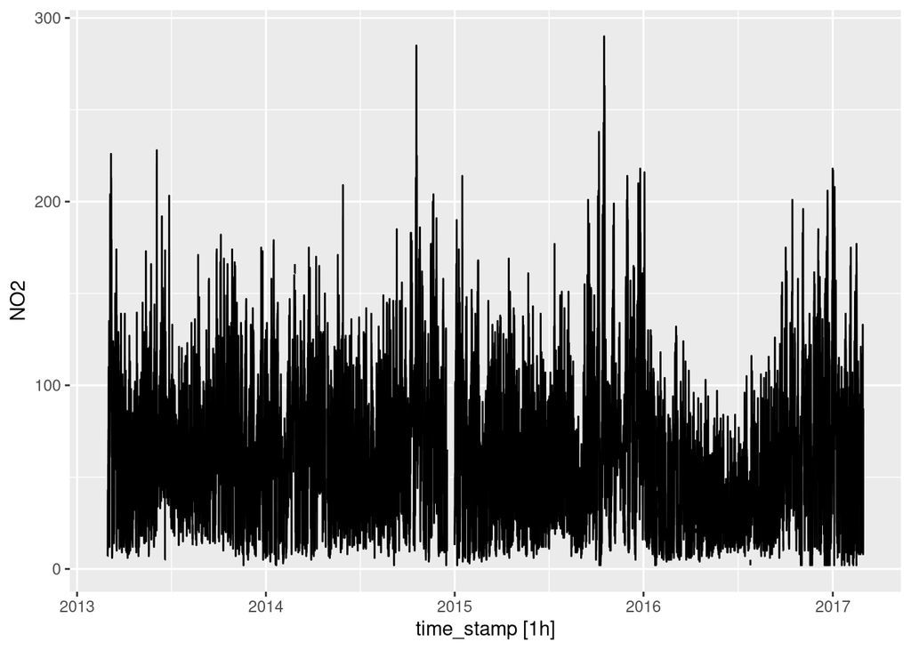

```r
autoplot(pollution, NO2)
```

## 1.1 Average weekly values

Use `index_by()` to define a new tsibble `NO2_weekly` that aggregates the hourly values in the tsibble `pollution` into average weekly NO2 levels. For details on how to use `index_by()`, refer to the tsibbles notebook from Session 3.

Then add a new column to `NO2_weekly` that holds the combination of year and month for each row.

Finally, filter the dataset to keep only values between March 2013 (included) and March 2014 (excluded).

## 1.2 Timeplot using weekly data

Create a timeplot using `NO2_weekly`. The timeplot must have a major break every month. Desired output below:

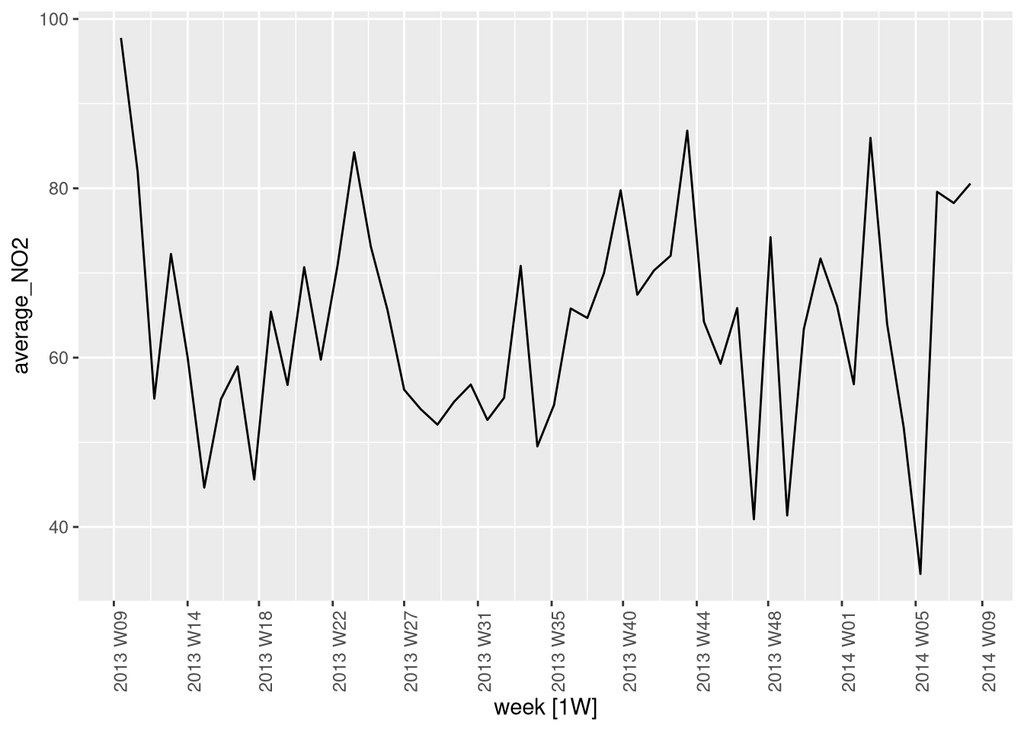

## 1.3 Monthly aggregation

Repeat the tasks from 1.1 and 1.2, but this time aggregate to monthly values and store the result in `NO2_monthly`. Then create a plot of that data with ticks every month:

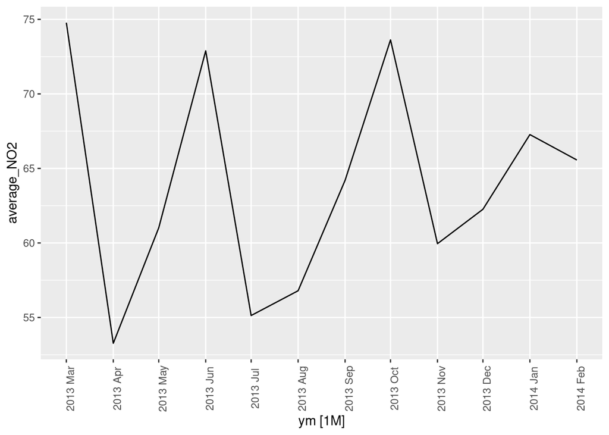

# 2. Fuel Prices

The code below turns the data in the file `Weekly Fuel Prices.xlsx` into a tsibble. The file is in the `data/` folder at the repository root:

```r
fuel_prices <-

  # Read excel file
  read_xlsx("../../data/Weekly Fuel Prices.xlsx",
            col_types = c ("date", "numeric", "numeric")) |>

  filter(!is.na(Date)) |>

  pivot_longer(cols = c("Petrol (USD)", "Diesel (USD)"),
               names_to = "fuel_type",
               values_to = "price_USD"
               ) |>

  as_tsibble(key =  fuel_type, regular = FALSE, index = Date)

fuel_prices
```

## 2.1 Quarterly aggregation with index_by

The code below produces the average quarterly prices, separated by `fuel_type`.

Run it with and without the `group_by(fuel_type)` line that precedes `index_by(yq = yearquarter(Date))`. How does the result change? Drop it and petrol and diesel are averaged together into a single meaningless series — a silent wrong answer that no warning will catch for you.

For the next section, keep the `group_by()` and store the result in `fuel_quarterly`.

```r
fuel_quarterly <-

  fuel_prices |>

  # Use group_by so that the subsequent index_by is applied
  # group-wise.
  group_by(fuel_type) |>

  # Index by yearquarter
  index_by(yq = yearquarter(Date)) |>

  # Summarise
  summarise(
      # One mean per fuel_type per quarter, so the name must not say "petrol"
      mean_price_USD = mean(price_USD, na.rm = TRUE)
  ) |>

  ungroup()
```

## 2.2 Time-plot

Filter the object `fuel_quarterly` to contain only the years 2004 to 2008 (both included).

Then produce the graph below, with major ticks every year and minor ticks every quarter.

```
Plot variable not specified, automatically selected `.vars = mean_price_USD`
```

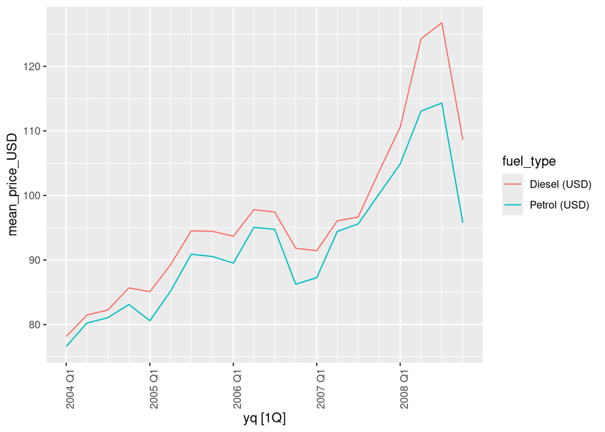